# Analyzing What Brings or Prevents People to Fitness

### Fitness refers to maintaining good health by being physically active. It is not only physical exercise that imrpove ones overall well-being, but mental activites as well. There are a large number of activites that can challenge one's physical and mental stregth and endurance.

### People take on fitness in numerous ways, which could include following specific training programs, sports, or even taking the time outside for a small period of time, as long as they enjoy it and can do it consistently.

### Physical activity time ranges by a peron's goals and activites, but is also affected by their personal life, which can be time commitment issues, lack of motivation, or simply don't enjoy it. It is recommended a person spends a minimum of at least 150 minutes of physical activity at a moderate-intensity and 2 days of activity that strength the muscles, according to the CDC. Strength training improves overall maintanence and improves muscle mass, balance, and endurance.

### While the first thing that comes to mind when fitness is mentioned is physical and mental training, it is also important to maintain a healthy balanced diet, at least seven hours of sleep, and managing stress.

### Fitness has been my favorite interest in maintaing a healthy lifestyle and decided to take a look at what factors help or prevent people from staying actively fit. The goal of this analysis is to identify what factors related to exercise influences a person overall health!

# Imports

```python
import pandas as pd
import matplotlib.pyplot as plt
import seaborn as sns

from sklearn import datasets, neighbors
from sklearn.model_selection import train_test_split
from sklearn.datasets import load_diabetes
from sklearn.ensemble import RandomForestClassifier
from sklearn.metrics import accuracy_score
from sklearn.neighbors import KNeighborsClassifier
from sklearn.metrics import classification_report
```

# Data Collection

### The first step in analyzing data is having actual data! This data was a survey collected by a college student from his friends and family about their fitness practices. The data is divided into 18 columns: name, gender, age, importance of exercise, fitness level, exercise frequency, barriers, type of exercise, who they exercise with, time of day, balanced diet, barriers in healthy diet, purchased equipment, and motivation.

```python
data = pd.read_csv('fitness analysis.csv')
# Drop any NaN values that are in the dataset, which is apart of the cleaning process
data.dropna()
data.head()
```

|  | Timestamp | Your name | Your gender | Your age | How important is exercise to you ? | How do you describe your current level of fitness ? | How often do you exercise? | What barriers, if any, prevent you from exercising more regularly? (Please select all that apply) | What form(s) of exercise do you currently participate in ? (Please select all that apply) | Do you exercise ___________ ? | What time if the day do you prefer to exercise? | How long do you spend exercising per day ? | Would you say you eat a healthy balanced diet ? | What prevents you from eating a healthy balanced diet, If any? (Please select all that apply) | How healthy do you consider yourself? | Have you ever recommended your friends to follow a fitness routine? | Have you ever purchased a fitness equipment? | What motivates you to exercise? (Please select all that applies ) |
| --- | --- | --- | --- | --- | --- | --- | --- | --- | --- | --- | --- | --- | --- | --- | --- | --- | --- | --- |
| 0 | 2019/07/03 11:48:07 PM GMT+5:30 | Parkavi | Female | 19 to 25 | 2 | Good | Never | I don't have enough time;I can't stay motivated | I don't really exercise | I don't really exercise | Early morning | I don't really exercise | Not always | Ease of access to fast food;Temptation and cra... | 3 | Yes | No | I'm sorry ... I'm not really interested in exe... |
| 1 | 2019/07/03 11:51:22 PM GMT+5:30 | Nithilaa | Female | 19 to 25 | 4 | Very good | Never | I don't have enough time;I'll become too tired | Walking or jogging;Swimming | With a group | Early morning | I don't really exercise | Not always | Ease of access to fast food;Temptation and cra... | 4 | Yes | No | I want to be fit;I want to be flexible;I want ... |
| 2 | 2019/07/03 11:56:28 PM GMT+5:30 | Karunya v | Female | 15 to 18 | 3 | Good | 1 to 2 times a week | I can't stay motivated | Walking or jogging | Alone | Early morning | 30 minutes | Not always | Temptation and cravings | 4 | Yes | Yes | I want to be fit |
| 3 | 2019/07/04 5:43:35 AM GMT+5:30 | Anusha | Female | 15 to 18 | 4 | Good | 3 to 4 times a week | I don't have enough time | Walking or jogging;Gym;Lifting weights | Alone | Evening | 1 hour | Yes | Temptation and cravings | 4 | Yes | No | I want to be fit;I want to lose weight |
| 4 | 2019/07/04 5:44:29 AM GMT+5:30 | Nikkitha | Female | 19 to 25 | 3 | Unfit | Never | I can't stay motivated | I don't really exercise | I don't really exercise | Evening | I don't really exercise | Yes | Ease of access to fast food;Temptation and cra... | 4 | Yes | No | I want to be fit |

# Cleaning the data

### There are certain columns that aren't necessarily important to look at or to have our training model later use as a factor for any predictions. Timestamp, the time in which the survey was recorded, is not relevant to any data. A person's name doesn't affect a peron's fitness. Therefore, we shall remove it.

```python
data = data.drop(columns='Your name ')
data = data.drop(columns='Timestamp')
data.head()
```

|  | Your gender | Your age | How important is exercise to you ? | How do you describe your current level of fitness ? | How often do you exercise? | What barriers, if any, prevent you from exercising more regularly? (Please select all that apply) | What form(s) of exercise do you currently participate in ? (Please select all that apply) | Do you exercise ___________ ? | What time if the day do you prefer to exercise? | How long do you spend exercising per day ? | Would you say you eat a healthy balanced diet ? | What prevents you from eating a healthy balanced diet, If any? (Please select all that apply) | How healthy do you consider yourself? | Have you ever recommended your friends to follow a fitness routine? | Have you ever purchased a fitness equipment? | What motivates you to exercise? (Please select all that applies ) |
| --- | --- | --- | --- | --- | --- | --- | --- | --- | --- | --- | --- | --- | --- | --- | --- | --- |
| 0 | Female | 19 to 25 | 2 | Good | Never | I don't have enough time;I can't stay motivated | I don't really exercise | I don't really exercise | Early morning | I don't really exercise | Not always | Ease of access to fast food;Temptation and cra... | 3 | Yes | No | I'm sorry ... I'm not really interested in exe... |
| 1 | Female | 19 to 25 | 4 | Very good | Never | I don't have enough time;I'll become too tired | Walking or jogging;Swimming | With a group | Early morning | I don't really exercise | Not always | Ease of access to fast food;Temptation and cra... | 4 | Yes | No | I want to be fit;I want to be flexible;I want ... |
| 2 | Female | 15 to 18 | 3 | Good | 1 to 2 times a week | I can't stay motivated | Walking or jogging | Alone | Early morning | 30 minutes | Not always | Temptation and cravings | 4 | Yes | Yes | I want to be fit |
| 3 | Female | 15 to 18 | 4 | Good | 3 to 4 times a week | I don't have enough time | Walking or jogging;Gym;Lifting weights | Alone | Evening | 1 hour | Yes | Temptation and cravings | 4 | Yes | No | I want to be fit;I want to lose weight |
| 4 | Female | 19 to 25 | 3 | Unfit | Never | I can't stay motivated | I don't really exercise | I don't really exercise | Evening | I don't really exercise | Yes | Ease of access to fast food;Temptation and cra... | 4 | Yes | No | I want to be fit |

```python
count_nofitness = len(data[data['What form(s) of exercise do you currently participate in ?                        (Please select all that apply)'].str.contains('I don\'t really exercise')])
count_fitness = len(data) - count_nofitness

print("Total number of people who don't participate in exercising = " + str(count_nofitness))
print("Total number of people who participate in exercising = " + str(count_fitness))

print("Percentage of people who work don't participate in exercising = " + str(count_nofitness/(len(data))))
print("Percentage of people who do participate in exercising = " + str(count_fitness/len(data)))
```

```
Total number of people who don't participate in exercising = 90
Total number of people who participate in exercising = 455
Percentage of people who work don't participate in exercising = 0.1651376146788991
Percentage of people who do participate in exercising = 0.8348623853211009
```

```python
data.columns
```

```
Index(['Your gender ', 'Your age ', 'How important is exercise to you ?',
       'How do you describe your current level of fitness ?',
       'How often do you exercise?',
       'What barriers, if any, prevent you from exercising more regularly?           (Please select all that apply)',
       'What form(s) of exercise do you currently participate in ?                        (Please select all that apply)',
       'Do you exercise ___________ ?',
       'What time if the day do you prefer to exercise?',
       'How long do you spend exercising per day ?',
       'Would you say you eat a healthy balanced diet ?',
       'What prevents you from eating a healthy balanced diet, If any?                         (Please select all that apply)',
       'How healthy do you consider yourself?',
       'Have you ever recommended your friends to follow a fitness routine?',
       'Have you ever purchased a fitness equipment?',
       'What motivates you to exercise?         (Please select all that applies )'],
      dtype='object')
```

# Data Exploration

```python
data.columns
```

```
Index(['Your gender ', 'Your age ', 'How important is exercise to you ?',
       'How do you describe your current level of fitness ?',
       'How often do you exercise?',
       'What barriers, if any, prevent you from exercising more regularly?           (Please select all that apply)',
       'What form(s) of exercise do you currently participate in ?                        (Please select all that apply)',
       'Do you exercise ___________ ?',
       'What time if the day do you prefer to exercise?',
       'How long do you spend exercising per day ?',
       'Would you say you eat a healthy balanced diet ?',
       'What prevents you from eating a healthy balanced diet, If any?                         (Please select all that apply)',
       'How healthy do you consider yourself?',
       'Have you ever recommended your friends to follow a fitness routine?',
       'Have you ever purchased a fitness equipment?',
       'What motivates you to exercise?         (Please select all that applies )'],
      dtype='object')
```

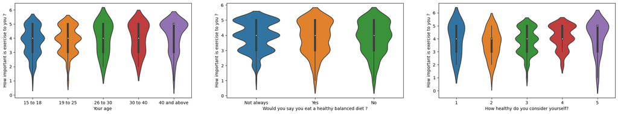

```python
f, axes = plt.subplots(ncols=3, figsize=(25,4))

sns.violinplot(y="How important is exercise to you ?", x='Your age ', data=data, order=['15 to 18', '19 to 25', '26 to 30', '30 to 40', '40 and above'], ax = axes[0])
sns.violinplot(y="How important is exercise to you ?", x='Would you say you eat a healthy balanced diet ?', data=data, ax = axes[1])
sns.violinplot(y="How important is exercise to you ?", x='How healthy do you consider yourself?', data=data, ax = axes[2])

plt.show()
```

### Taking a look at the set of violin plots, we are looking to see if age, balanced diet, or how they view themselves affects how important exercise is to them. Taking a look at the violin plot with age and importance, we'll call that Plot 1, it can be seen that as a person get's older, the importance of exercise goes up. The 15-18 and 19-25 year old age group had a bigger mode at 4, and as the ages increases, the mode tends to be more skewed toward a rating of 5 importance.

### Taking a look at the middle plot, we'll call that Plot 2, a balanced diet can be seen to not very much affect exercise importance. We can conlude that eating healthier does not increase a person's odds to increase their importance of exercise.

### Taking a look at the right plot, we'll cal that Plot 3, we are looking at how healthy one considers themselves and their importance of exercise based on that. For someone who doesn't think they are not healthy, they actually have a higher average exercise importance level. This could be as a result of wanting to get healthier. As we go on, people who are averagely healthy priotize exercise on a 3 or 4 scale. But as soon as we get to the healthier self-considered people, exercise is very important to them. Thus, we can conclude that exercise increases a person's thoughts on how healthy they are.

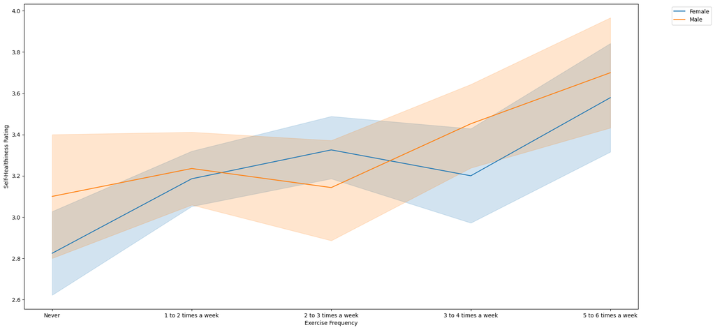

```python
fig, ax = plt.subplots()

# Set categorical order
data['How often do you exercise?'] = pd.Categorical(data['How often do you exercise?'], categories=['Never', '1 to 2 times a week', '2 to 3 times a week', '3 to 4 times a week', '5 to 6 times a week', 'Everday'], ordered=True)
ax = sns.lineplot(data=data, x='How often do you exercise?', y='How healthy do you consider yourself?', hue='Your gender ')
# Change x and y labels
ax.set(xlabel='Exercise Frequency', ylabel='Self-Healthiness Rating')
# Move legend outside line graph
plt.legend(bbox_to_anchor=(1.05, 1), loc=2)
# Rearrange the size of the graph
fig.set_size_inches(20, 10)
plt.show()
```

### Since in the last set of plots we saw that self-healthiness rating has a relationship to how important exercise is, let's take a look on how exercise frequency affects one's self-healthiness rating. Exercise frequency is broken up into 5 categories: 'Never', '1 to 2 times a week', 2 to 3 times a week', '3 to 4 times a week', and '5 to 6 times a week. As we can see from this line graph, the more frequent one works out, the healthier they believe to be. Despite gender, it is an increasing trend for both. From here, we can conlude that exercise is important to all, but more important to those who are consider themselves the least healthiest or most healthiest. And from this graph, their healthiness rating is dependent on their exercise frequency.

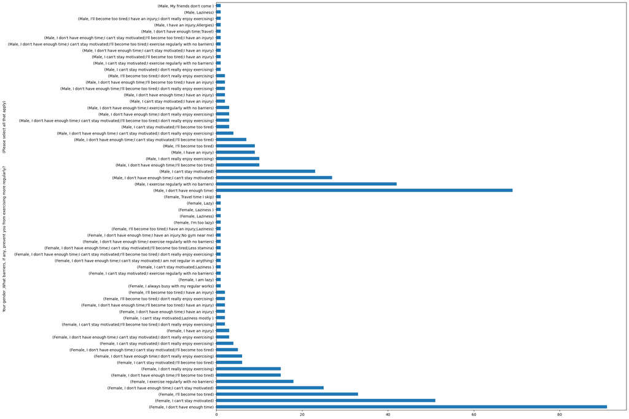

```python
fig, ax = plt.subplots()
# Grouping the data by gender and determining the barriers that affect each
counts = data.groupby('Your gender ')['What barriers, if any, prevent you from exercising more regularly?           (Please select all that apply)'].value_counts()
# Resizing the plot to make the axis more legible
fig.set_size_inches(20, 20)
counts.plot(kind='barh')
plt.show()
```

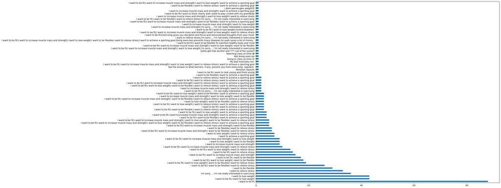

```python
fig, ax = plt.subplots()
counts = data['What motivates you to exercise?         (Please select all that applies )'].value_counts()
fig.set_size_inches(20, 15)
counts.plot(kind='barh')
plt.show()
```

### We are now exploring what reasons people have for having a lower frequency of exercising or why they do not exercise at all. A majority of people said that they do not have time. However, there are a number of solutions that these people could consider in order to maintain a healthy lifestyle:

### 1. Fitting in shorter workouts instead of one long workout. As little as 10 minutes of active training to increase your heart rate is good for cardiovascular health

### 2. Incorporate physical activity into your daily routine. There are ways throughout the day where people can incorporate physical activity while they are busy during their day. Walking to public transportation instead of driving, a leisure break outside during break time, or even yoga while watching TV at night.

### 3. Workouts that can be just as effective as more intense workouts, but are easier on the body and may be more suitable for those who are short on time or energy are biking, swimming, or pilates.

### 4. It is important to relieve stress! In the second bar chart, roughly 35 people said that they would like to relieve stress as a motive for working out. Other motives include losing weight and wanting to be fit. Although that may not apply to everyone, stress is overall good for every day-to-day life functionality.

# Classifier

## In this section, we will be attempting to train our classifier

```python
data = pd.get_dummies(data, columns=['Your gender ', 'Your age ', 'How important is exercise to you ?',
       'How do you describe your current level of fitness ?',
       'How often do you exercise?',
       'What barriers, if any, prevent you from exercising more regularly?           (Please select all that apply)',
       'What form(s) of exercise do you currently participate in ?                        (Please select all that apply)',
       'Do you exercise ___________ ?',
       'What time if the day do you prefer to exercise?',
       'How long do you spend exercising per day ?',
       'Would you say you eat a healthy balanced diet ?',
       'What prevents you from eating a healthy balanced diet, If any?                         (Please select all that apply)',
       'Have you ever recommended your friends to follow a fitness routine?',
       'Have you ever purchased a fitness equipment?',
       'What motivates you to exercise?         (Please select all that applies )'])

target = data['How healthy do you consider yourself?']
data = data.drop('How healthy do you consider yourself?', axis = 1)

X_train, X_test, y_train, y_test = train_test_split(data, target, test_size = .2, random_state = 0)

forest = RandomForestClassifier()
forest.fit(X_train, y_train)
y_pred = forest.predict(X_test)
accuracy_score(y_test, y_pred)
```

```
0.6330275229357798
```

## Classifier Results

```python
print('Decision Tree Classifier')
print(classification_report(y_test, y_pred))
```

```
Decision Tree Classifier
              precision    recall  f1-score   support

           1       0.00      0.00      0.00         2
           2       0.00      0.00      0.00         7
           3       0.66      0.89      0.76        65
           4       0.50      0.31      0.38        29
           5       0.67      0.33      0.44         6

    accuracy                           0.63       109
   macro avg       0.37      0.31      0.32       109
weighted avg       0.56      0.63      0.58       109
```

Our model shows that the model has a precision score of 0 for the first two classes, .66 for class 3, .50 for class 4, and .67 for class 5. The F1-score is a balanced measure of precision and recall, with class 1 and class 2 having scores of 0 and class 3, class 4, and class 5 having .76, .38, and .44 respectively. The weighted average of the f1-score has a .58 rating, which somewhat takes in the imbalances of each class.

# Conclusion

While data exploration has showed us the correlation between exercise frequency, self-healthiness rating, and the importance of exercise. With the our classifier having a poor performance in classifying examples and classes, we can conclude that although there lies a relationship between exercising and healthiness, every person in the dataset has their own opinions about themselves and their classification on how they view healthiness or what they consider healthy. Changing any of the factors for a person wouldn't increase a person's interest in fitness, but rather informing them on the the little things they can do in their day to exercise to boost change what they classify as exercising or healthiness, which can overall improve their health.